# STAT340: Discussion 8: Linear regression

## XKCD comic

[figure not shown]

## Exercise: modeling earthquake frequency and intensity

Today, we will be using real data from the [US Geological Survey (USGS)](https://www.usgs.gov/natural-hazards/earthquake-hazards/earthquakes) to build a model to estimate how the intensity of earthquakes relates to their frequency around the world.

As usual, we encourage you to work in small groups, but this is up to you.

### Background

In seismology, the study of earthquakes, the relationship between the frequency and magnitude of earthquakes can be modeled by the [Gutenberg-Richter (GR) law](https://en.wikipedia.org/wiki/Gutenberg%E2%80%93Richter_law). Let $M$ be the [Richter magnitude](https://en.wikipedia.org/wiki/Richter_magnitude_scale) of a seismic event (roughly speaking, the amount of energy released by an earthquake), and $N$ be the number of events with magnitude **at least $M$** (i.e., greater than or equal to $M$). The GR law states that
$$N \approx 10^{a-bM},$$

where $a$ and $b$ are constants that depend on the particular choice of place/period. In other words, taking the logarithm of both sides,
$$\log_{10}(N) \approx a-bM$$

Note that this relationship should appear as a straight line if we plot $\log_{10}(N)$ as a function of $M$.

This linear relationship between the log of the number of earthquakes of a given magnitude and the magnitude suggests that we can use linear regression to estimate the values of $a$ and $b$. Let’s do that!

### Importing the data

Our dataset contains every earthquake (on Earth) of magnitude 4.5 or greater that was detected by USGS from beginning of 2011 to end of 2021. A detailed description of the columns can be found [here](https://earthquake.usgs.gov/data/comcat/data-eventterms.php), but the main variables we are interested in for the purposes of this exercise are are `time` (self explanatory) and `mag.binned` (magnitude rounded to nearest half integer).

For convenience, much of the data cleaning and preprocessing has already been done for you. You can download the prepared data [here](https://pages.stat.wisc.edu/~kdlevin/teaching/Fall2022/STAT340/discussion/ds08/quakes.csv) or from canvas. Be sure to save this file in the same directory as where you are running this source file. If you’re not sure, run `getwd()` to ask R for the current working directory and save the file there.

```r
quakes <- read.csv( 'quakes.csv' )
```

Since this is a bit tricky, it’s been done for you below using tidyverse tools. We recommend that you read through this block of code carefully to make sure you have at least a high-level understanding of what it is doing. It is good to get practice with these sorts of data processing tricks, even if they aren’t the main point of the course.

```r
library(tidyverse)
quakes.count <- quakes %>%
   count(year,mag.binned,name='count') %>%
   group_by(year) %>%
   mutate(N=rev(cumsum(rev(count))), year=as.character(year))

# NOTES:
# count(year,mag.binned) counts how many events with that magnitude occurred each year
#   (see https://dplyr.tidyverse.org/reference/count.html for more info)
#
# group_by(year) followed by cumsum(...) takes the cumulative sum in each year
# the rev(...rev(...)) runs this cumsum in reverse (otherwise we get ≤M instead of ≥M)
```

Before moving onto the next step, inspect the data frame to make sure you completely understand what it represents and check that everything looks right. Your first and last rows should look something like `2011, 4.5, 7430, 10636` and `2021, 8.0, 2, 2`.

```r
print(quakes.count,n=Inf)
```

```
## # A tibble: 90 × 4
## # Groups:   year [11]
##    year  mag.binned count     N
##    <chr>      <dbl> <int> <int>
##  1 2011         4.5  7430 10636
##  2 2011         5    2485  3206
##  3 2011         5.5   395   721
##  4 2011         6     236   326
##  5 2011         6.5    62    90
##  6 2011         7      21    28
##  7 2011         7.5     6     7
##  8 2011         8       1     1
##  9 2012         4.5  6136  9195
## 10 2012         5    2461  3059
## 11 2012         5.5   402   598
```

[output cut: 79 more lines]

**Question:** to check your understanding: what does each row in the data frame `quakes.count` represent? Given that we are going to treat each of these rows as an observation in our data, which column is the predictor in our regression described above? Which column is the response variable?

### Visualization

As usual, our first step is to visualize the data. Make a *scatter plot* of $\log_{10}(N)$ as a function of $M$. Note that this means $M$ is on the horizontal axis (we say “$y$ as a function of $x$, not”$x$ as a function of $y$“). Then, add a line plot on top showing the trajectory of each year, making sure the years are correctly grouped together and distinguished from each other. You might use something like `color` or `linetype`, or even something else; use your best judgment.

**Note:** you can either use `log10(N)` as the `y` aesthetic, OR directly use `y=N` and just rescale the axis to be logarithmic using `scale_y_log10()`. I recommend this second method since it makes the axis easier to read (see [here](https://stackoverflow.com/a/9223257) for an example).

It should look something like this (don’t forget to add a nice title and axis labels to your plot!):

[figure not shown]

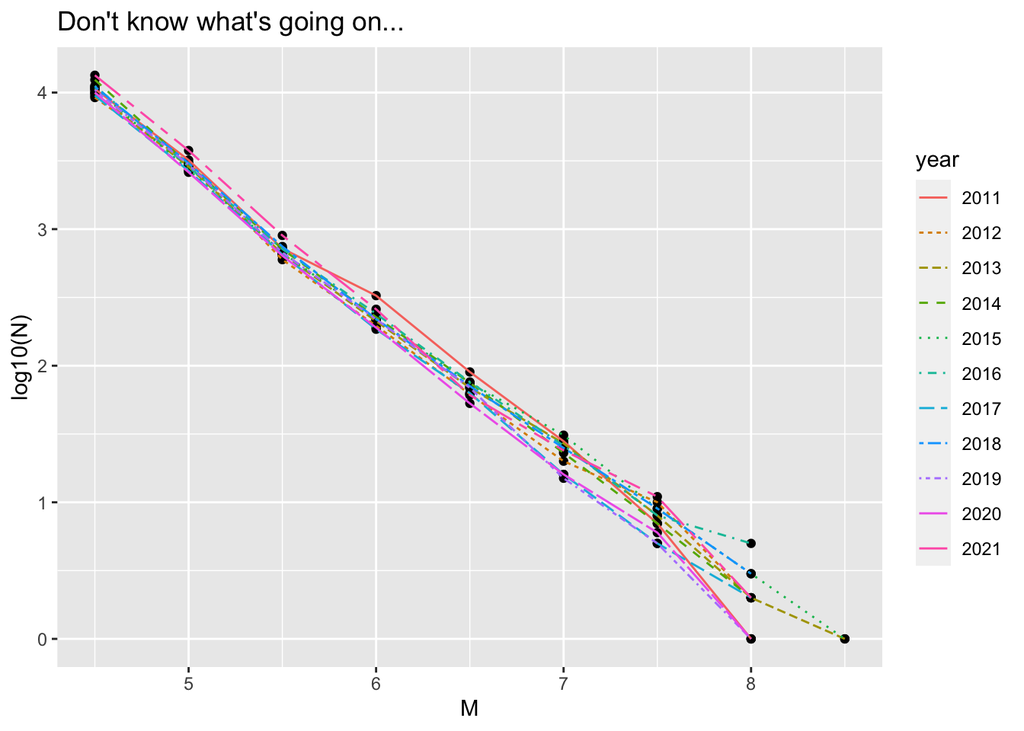

```r
# TODO: uncomment and fill in the code below.
ggplot(quakes.count, aes(x = mag.binned, y = log10(N))) +
  geom_point() + geom_line(aes(linetype = year, color = year)) +
  xlab("M") +
  ylab("log10(N)") +
  ggtitle("Don't know what's going on...")
```

### Estimation

Next, we will fit a simple linear regression to the data to estimate $a$ and $b$. Complete the line of code below to fit the model (don’t forget the linear relationship is NOT between $N$ and $M$ but rather between $\log_{10}(N)$ and $M$, so adjust your model formula accordingly!).

```r
#TODO: uncomment and fill in the code below.
lm.quakes <- lm(formula = log10(N) ~ 1 + mag.binned, data = quakes.count);
```

View a summary of the model to see the coefficient estimates, $p$-values, and other relevant info.

```r
#TODO: uncomment the code below.
summary(lm.quakes)
```

```
##
## Call:
## lm(formula = log10(N) ~ 1 + mag.binned, data = quakes.count)
##
## Residuals:
##      Min       1Q   Median       3Q      Max
## -0.30836 -0.06381  0.00113  0.06619  0.39061
##
## Coefficients:
##             Estimate Std. Error t value Pr(>|t|)
## (Intercept)  8.65811    0.06598   131.2   <2e-16 ***
## mag.binned  -1.04372    0.01029  -101.4   <2e-16 ***
## ---
## Signif. codes:  0 '***' 0.001 '**' 0.01 '*' 0.05 '.' 0.1 ' ' 1
##
## Residual standard error: 0.1153 on 88 degrees of freedom
## Multiple R-squared:  0.9915, Adjusted R-squared:  0.9914
## F-statistic: 1.028e+04 on 1 and 88 DF,  p-value: < 2.2e-16
```

From your fit, what are your estimates for the constants $a$ and $b$? Pay **careful attention** to the signs here! (hint: remember the GR law uses the convention $a-bM$ whereas R assumes you are fitting `intercept + slope * M`, so your fitted slope is $-b$).

Try to avoid copy-pasting or manually typing in values. The `coef()` function lets you extract coefficients from a model object (e.g. `lm.quakes`), or you can access the `coefficients` attribute of your fitted model directly. The result will be a vector, and you can then use `[i]` to access the i-th value of this coefficients vector. You may also want to use `unname()` at the end to remove the name from the value. If you don’t, it may carry through to later calculations and interfere with some downstream code.

```r
# TODO: uncomment and fill in code below
a <- unname(lm.quakes$coefficients[1])
b <- unname(-lm.quakes$coefficients[2])
```

**Hint:** if you did this correctly, `a+b` should evaluate to approximately `9.7`.

### Checking fit

It’s always nice to *visually check your fit* to make sure everything looks right. Plot the line of best fit along with the data points in the chunk below.

**Hint:** this time, we recommend using `log10(N)` as the `y` aesthetic, then using [`geom_abline()`](https://ggplot2.tidyverse.org/reference/geom_abline.html) to plot your regression lines using your estimated slope and intercept values. This avoids dealing with distorted axis caused by the other method’s `scale_y_log10()` which can be non-intuitive to deal with. Note that you can use your variables `a` and `b` here that were defined previously to avoid manually typing in numerical estimates (which is almost always bad!).

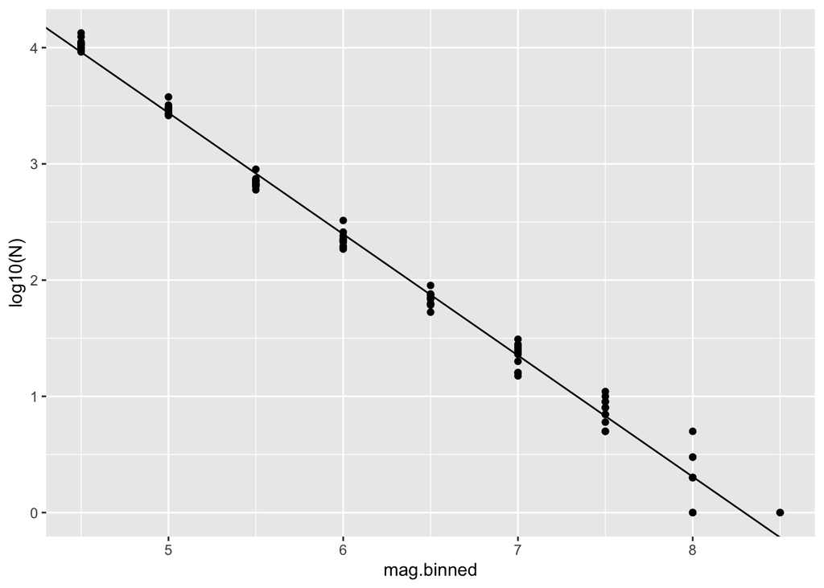

```r
# TODO: uncomment and complete the code.
ggplot(quakes.count, aes(x = mag.binned, y = log10(N))) +
  geom_point() +
  geom_abline(slope = -b, intercept = a)
```

You can also check [the residuals of your fit](https://rpubs.com/iabrady/residual-analysis). This is fairly convenient to do in base R. Note that you will see some **heteroscedasticity** due to the fact that higher magnitude earthquakes occur much less frequently than lower magnitude earthquakes (thank goodness!), so we expect there to be more variation in our estimates for those magnitudes. This is to be expected, and not a huge problem. Aside from these extremes, you should be able to see that normality is mostly satisfied.

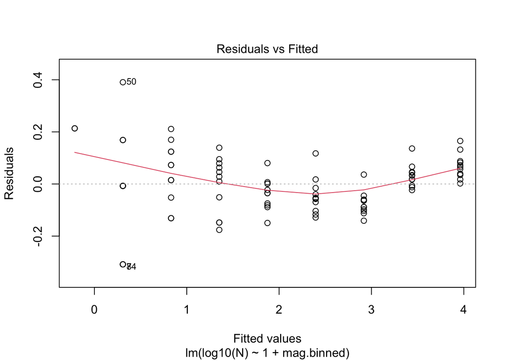

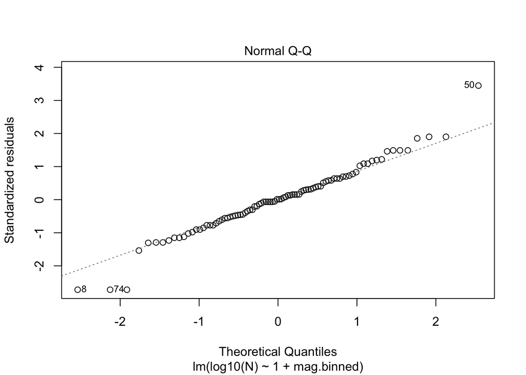

```r
plot(lm.quakes,which=1:2)
```

### Confidence intervals

Give $95\%$ confidence intervals for $a$ and $b$ (here is a [help page](https://www.rdocumentation.org/packages/stats/versions/3.6.2/topics/confint), if you need it).

```r
confint(lm.quakes, alpha = .05)
```

```
##                 2.5 %    97.5 %
## (Intercept)  8.526988  8.789238
## mag.binned  -1.064177 -1.023262
```

Give a brief interpretation of these intervals.

If we followed the same linear regression procedure on data from experiments similarly constructed, in 95% of them we would expect to find the true intercept/Beta0 and the true slope/Beta1.

### Making predictions

Let $N_{\ge 5}$ denote the number of earthquakes of magnitude 5 or greater should we expect to see on average each year. According to your estimated model, what is the approximate value of $N_{\ge 5}$? Give a brief explanation of your reasoning below.

```r
# log10(N) = a - bM
```

According to your model, you would expect to see an earthquake with magnitude between 9.5 and 10 on average *once every how many years*? Explain your reasoning below. **Hint:** be careful– we have computed how many earthquakes happen per year, so to determine how many years there are *between* high-magnitude years we should… Also be careful about the part where we want to count earthquakes with magnitude 9.5 or 10, but not bigger and not smaller!

```r
# TODO: perform calculations here
```

From the [GR law](https://en.wikipedia.org/wiki/Gutenberg%E2%80%93Richter_law#Background), we can deduce that the total number of earthquakes of magnitude at least $0$ is given by
$$N_\text{Total}=10^{a}.$$
Using your estimate for $a$, approximately how many earthquakes are there in total every year on Earth?

Still, let’s have a look. Use the box below to compute your answer.

```r
# TODO: perform calculations here
```

Realistically, this estimate is probably only good to a few significant figures. Thus, rather than giving a precise point estimate, let’s construct a confidence interval.

```r
# TODO: perform calculations here
```